# Mental Health in the Tech Industry — Exploration

In this analysis, I will be exploring the Mental Health in the Tech Industry dataset to better understand how mental health issues manifest within the tech field. The goals of this analysis include:

- Preparing the data by joining relevant tables, removing duplicates, and handling inconsistencies where needed.
- Understanding the demographics of the respondents: age, gender, and distribution.
- Analyzing mental health indicators, including current, past, and diagnosed mental health disorders.
- Incorporating prevalence rates and associated confidence intervals into the analysis.
- Examining relationships between mental health, gender (e.g., are women more likely to report issues? Are they more likely to get diagnosed because of it?) and age (e.g., is mental health reporting more common in younger age groups?)

The notebook will present clear visualizations, interpretations of results, and reflections on uncertainty and potential limitations. The aim is not to be exhaustive, but to demonstrate thoughtful exploration of selected features within the dataset.

```python
query = """
SELECT
    A.*,
    Q.*,
    S.*
FROM
    Answer A
JOIN
    Question Q ON A.QuestionID = Q.questionid
JOIN
    Survey S ON A.SurveyID = S.SurveyID
"""
df = pd.read_sql_query(query, my_conn)
df.index = range(1,len(df) + 1)
```

### Dataset Overview

Immediately after the initial cleanup and overview, some aspects about the dataset became clear. This dataset includes responses to mental health surveys conducted in the tech industry during the years 2014, 2016, 2017, 2018, and 2019 (years corresponding to SurveyIDs and Descriptions). The data was originally provided as an SQLite database and consists of three joined tables. Here is more information about the data (based on the initial overview and the information provided when acquiring the dataset):

- **Total rows (records)**: `236,898`
- **Total unique survey questions**: `105`
- **Total unique user IDs**: `4218`
- **User responses include multiple rows per user**
- **I will be retaining missing or blank responses**, as non-response is itself meaningful in survey analysis.

## Analysis

It is already clear that the dataset contains responses from 4,218 unique participants, with a total of 236,898 responses across all questions. However, what else can be said about the participants and their mental health?

While there are many possible angles when it comes to analyzing this particular dataset - including features such as the country where respondents live, work, their race and more, in my analysis I will focus on the age, gender, remote work status and how these aspects relate to mental health related information that participants provide about themselves.

### Age

There's an exact number of answers as there are User IDs; however, there still might be some outliers or invalid responses. I am dividing all answers to the question "What is your age?" into groups to see how they distribute:

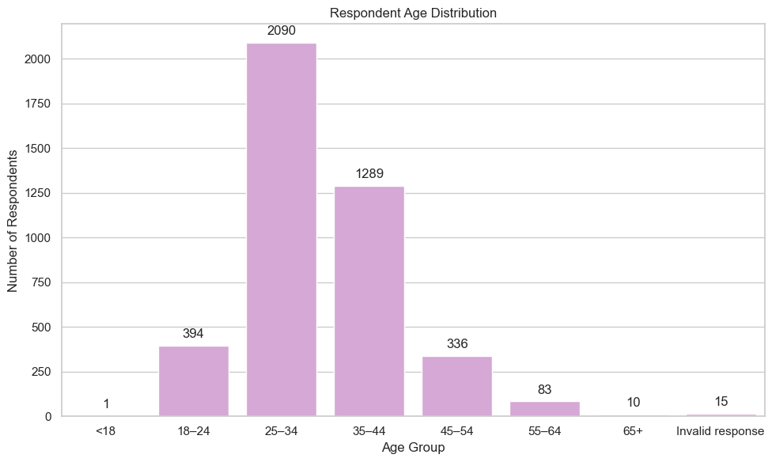

As you can see from the chart, the biggest portion of respondents (over 2000) are between the ages of 25 to 34. The next largest age group is 35-44.

There are 15 responses categorized as invalid or outliers; they are either outside a realistic age range or non-numeric. I am now taking a closer look at them. Seems like some respondents simply did not enter their real age.

```python
age_df = df[df["QuestionText"] == "What is your age?"].copy()
age_df["age_numeric"] = pd.to_numeric(age_df["AnswerText"], errors="coerce")

invalid_ages = age_df[
    (age_df["age_numeric"].isna())
    | (age_df["age_numeric"] < 16)
    | (age_df["age_numeric"] > 75)
]

invalid_age_counts = invalid_ages["AnswerText"].value_counts()
print("Invalid responses (outside 16–75 range or non-numeric):\n")
print(invalid_age_counts)
```

```
Invalid responses (outside 16–75 range or non-numeric):

AnswerText
-1     5
-29    1
329    1
5      1
8      1
11     1
99     1
323    1
3      1
15     1
0      1
Name: count, dtype: int64
```

### Gender

Gender is an important sociodemographic factor in this analysis, especially when evaluating how different groups may experience or report mental health conditions. In this section, I extract responses related to gender and begin normalizing the wide range of user-submitted values.

Since the gender field was open-ended, many respondents entered variations or typos (e.g., "malr", "cis-female"). To ensure consistency, these are grouped into standardized categories - Male, Female and Other (including non-binary, unspecified, or unclear responses).

This cleanup allows for meaningful comparisons in later stages of the analysis.

```python
gender_df = df[
    df["QuestionText"].str.lower().str.contains("your gender", na=False)
].copy()


def map_gender(g):
    if not isinstance(g, str):
        return "Other"

    g_lower = g.strip().lower()

    if g_lower in [
        "male",
        "m",
        "man",
        "cis male",
        "cis-male",
        "male-ish",
        "maile",
        "malr",
        "mail",
    ]:
        return "Male"
    elif g_lower in [
        "female",
        "f",
        "woman",
        "cis female",
        "cis-female",
        "femake",
        "female (cis)",
        "femail",
    ]:
        return "Female"
    else:
        return "Other"


gender_df["GenderCleaned"] = gender_df["AnswerText"].apply(map_gender)
gender_df["GenderCleaned"].value_counts()
```

```
GenderCleaned
Male      3045
Female    1024
Other      149
Name: count, dtype: int64
```

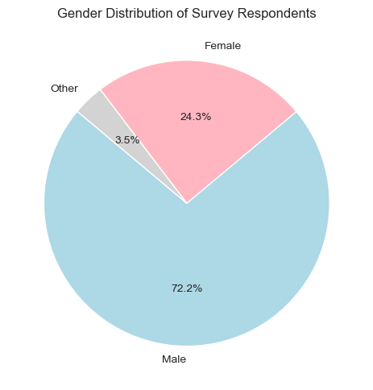

As shown in the pie chart above, the majority of respondents identified as Male, with a smaller portion identifying as Female, and a notable segment falling into the “Other” category. This category includes non-binary identities as well as ambiguous or invalid entries. The distribution is consistent with known gender imbalances in the tech industry, however, it included responses from multiple years. Did these percentages change over time?

To answer this question, we first need to take a look at the years indicated by the SurveyID:

- **Are some years overrepresented?**
- **Was the gender question asked every year?**
- **Can we make fair comparisons across years?**

| SurveyID | Total Respondents | Answered Gender | Coverage (%) |
| --- | --- | --- | --- |
| 2014 | 1260 | 1260 | 100.0 |
| 2016 | 1433 | 1433 | 100.0 |
| 2017 | 756 | 756 | 100.0 |
| 2018 | 417 | 417 | 100.0 |
| 2019 | 352 | 352 | 100.0 |

As you can see, the total number of survey respondents (and therefore the number of people who answered the gender question) varies significantly from year to year. To allow for a fair comparison of gender distribution across years without one year dominating the results due to sample size, I selected a smaller, balanced random sample from each year. This might help produce a clearer and more proportionally accurate trend when comparing.

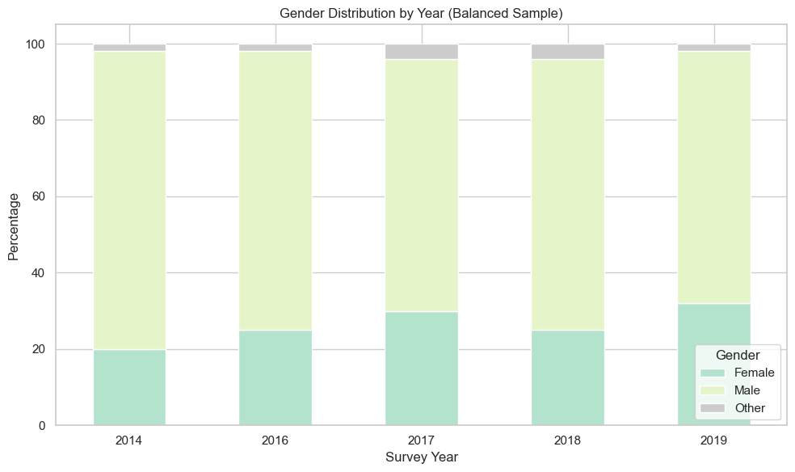

```python
sample_size = 100

sampled_gender_list = []

for year, group in gender_df.groupby("SurveyID"):
    sampled = group.sample(n=min(sample_size, len(group)), random_state=42)
    sampled_gender_list.append(sampled)

sampled_gender_df = pd.concat(sampled_gender_list).reset_index(drop=True)
sampled_gender_df["GenderCleaned"] = sampled_gender_df["AnswerText"].apply(map_gender)
counts = sampled_gender_df.groupby(["SurveyID", "GenderCleaned"]).size().unstack()
sampled_gender_over_time = counts.div(counts.sum(axis=1), axis=0).fillna(0) * 100


sampled_gender_over_time.plot(
    kind="bar", stacked=True, figsize=(10, 6), colormap="Pastel2"
)
plt.title("Gender Distribution by Year (Balanced Sample)")
plt.ylabel("Percentage")
plt.xlabel("Survey Year")
plt.xticks(rotation=0)
plt.legend(title="Gender")
plt.tight_layout()
plt.show()
```

[output not shown]

### Remote work

The dataset contains two different questions related to remote work, but each was only asked in one specific year:

- 2014: "Do you work remotely (outside of an office) at least 50% of the time?"
- 2016: "Do you work remotely?"

While these questions might provide some insight into remote work patterns, they appear in only 2 out of the 5 total survey years. The coverage is quite limited, which is disappointing as the linear progression until 2019 might have been an interesting feature to observe.

Remote work will not be included in deeper cross-year analyses in this project.

## Mental Health

While there's a variety of mental health related questions in the dataset, one of the most tangible ones I will first take a look at is "Do you currently have a mental health disorder?"

This question provides a snapshot of the respondents’ self-reported current mental health status. To simplify the analysis, I grouped the answers into three categories:

- **Yes**
- **No**
- **Uncertain** (includes ambiguous or unclear responses)

The following chart displays the number of responses for each group, along with their respective proportions.

```python
def group_mh_response(ans):
    if ans == "Yes":
        return "Yes"
    elif ans == "No":
        return "No"
    else:
        return "Uncertain"
```

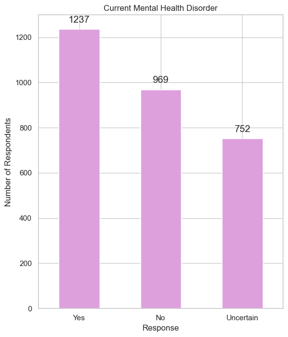

```
- Yes: 41.8%
- No: 32.8%
- Uncertain: 25.4%
```

```
count
1    2958
Name: count, dtype: int64
```

As you can see, over 41 percent of respondents answered yes, over 30 percent answered no, and the more ambiguous "Uncertain" group summed up to a quarter (possibly indicating lack of diagnosis, hesitation, or confusion about mental health status). This highlights a significant proportion of individuals in the tech industry who are either affected by mental health issues or unsure of their current condition. The large “Uncertain” group may suggest gaps in awareness or access to mental health resources, making it a key consideration in follow-up analysis.

It would be interesting to see how the results of people's answers in other fields compare to those in tech.

The next related question I am taking a look at is "Have you had a mental health disorder in the past?". This question offers insights into respondents’ mental health history.

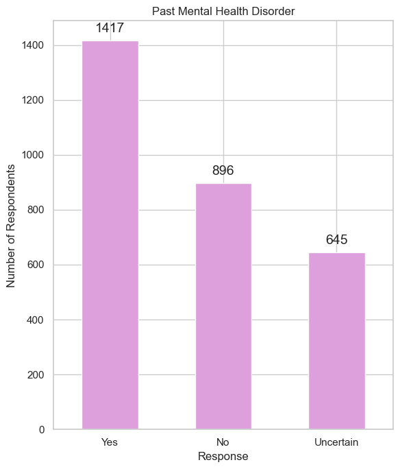

```
- Yes: 47.9%
- No: 30.3%
- Uncertain: 21.8%
```

```
count
1    2958
Name: count, dtype: int64
```

Compared to the current disorder rates, the percentage of “Yes” responses is slightly higher, suggesting that some individuals may have recovered or no longer identify as currently having a mental health disorder. This trend may also indicate improvements in treatment, awareness, or self-perception over time.

The third question focuses on formal diagnosis:

“Have you ever been diagnosed with a mental health disorder?”

This version of the question offers a more objective view - rather than relying on self-identification, it asks respondents to reflect on whether they’ve received a clinical diagnosis. This is important for understanding how many individuals not only experience symptoms but also access professional support and diagnosis.

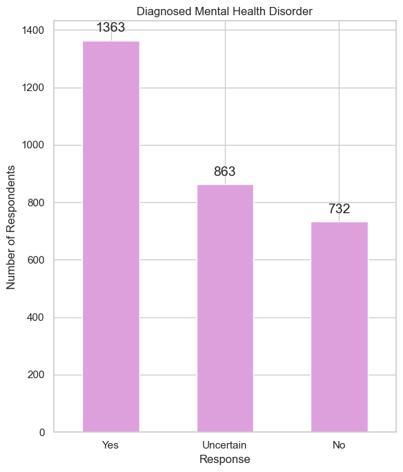

```
- Yes: 46.1%
- Uncertain: 29.2%
- No: 24.7%
```

```
count
1    2958
Name: count, dtype: int64
```

- 46 percent of respondents reported being formally diagnosed.
- Over 29 percent were uncertain, suggesting potential gaps in clarity, miscommunication during diagnosis, lack of access to medical evaluation, or dishonest input.
- 24% said No, which is lower than in previous questions.

The higher uncertainty rate compared to the other two questions may be due to the specificity of the term "diagnosed." Some individuals may have experienced symptoms but never consulted a professional.

One of the theories that first arises is the fact that the tech field is known for being heavily male-dominated (at least in the past), and there might be a higher stigma related to taking care of your mental health amongst males due to many factors. We will briefly revisit this notion further into the analysis.

### Prevalence Rates and Confidence Intervals

After the initial overview of the 3 questions, I will now take a more statistical approach.

To better understand how these rates might generalize beyond our sample, I calculated the prevalence rate (i.e., percentage of yes answers) along with a 95% confidence interval (CI) for each of the three key mental health questions:

```python
mh_questions = [
    "Do you currently have a mental health disorder?",
    "Have you had a mental health disorder in the past?",
    "Have you ever been diagnosed with a mental health disorder?",
]

results = []

for question in mh_questions:
    subset = df[df["QuestionText"] == question].copy()

    subset["CleanAnswer"] = subset["AnswerText"].apply(
        lambda x: "Yes" if x == "Yes" else ("No" if x == "No" else "Uncertain")
    )

    total = subset.shape[0]
    yes_count = (subset["CleanAnswer"] == "Yes").sum()
    proportion = yes_count / total

    ci_low, ci_high = proportion_confint(yes_count, total, alpha=0.05, method="wilson")

    results.append(
        {
            "Question": question,
            "Yes (%)": proportion * 100,
            "CI Lower": ci_low * 100,
            "CI Upper": ci_high * 100,
        }
    )

mh_ci_df = pd.DataFrame(results)
mh_ci_df
```

|  | Question | Yes (%) | CI Lower | CI Upper |
| --- | --- | --- | --- | --- |
| 0 | Do you currently have a mental health disorder? | 41.818796 | 40.052961 | 43.605854 |
| 1 | Have you had a mental health disorder in the p... | 47.903989 | 46.107606 | 49.705810 |
| 2 | Have you ever been diagnosed with a mental hea... | 46.078431 | 44.288375 | 47.878661 |

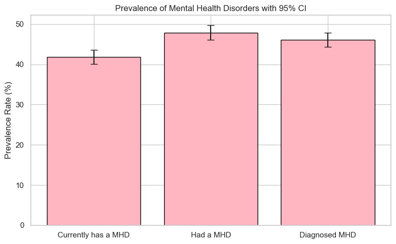

Some summaries and takeaways after taking a look at all 3 questions:

"Currently has a mental health disorder" shows a prevalence rate of about 42%, slightly lower than the other two. This may suggest that some individuals have experienced mental health issues in the past but are not currently affected.

"Had a mental health disorder in the past" has the highest rate (around 48%), indicating that nearly half of the respondents have struggled with mental health at some point in time.

"Diagnosed mental health disorder" falls just below that at 46%, showing that while many have been diagnosed, not everyone who has experienced issues may have received a diagnosis.

The confidence intervals around these estimates are quite narrow (approximately 2–3%), likely influenced by the relatively large sample sizes.

Overall, this snapshot confirms that mental health concerns are highly prevalent among tech industry professionals, whether currently ongoing, previously experienced, or clinically diagnosed. However, to truly understand the scale, further analysis is needed (to compare with data related to different fields for example)

## Mental Health and Gender Overview

I wanted to explore how mental health issues vary across genders, so I focused on the question “Do you currently have a mental health disorder?”. To make the comparison fair, I used a cleaned and balanced gender sample across survey years to avoid skewed results due to disproportionate participation.

For each, I calculated the prevalence rate along with a 95% confidence interval. This helps account for uncertainty and gives a clearer picture of how these rates might look in the wider population.

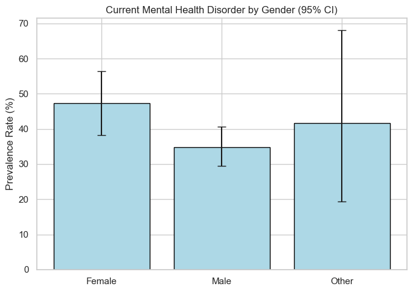

|  | Gender | Yes (%) | CI Lower | CI Upper |
| --- | --- | --- | --- | --- |
| 0 | Female | 47.32 | 38.32 | 56.50 |
| 1 | Male | 34.78 | 29.41 | 40.58 |
| 2 | Other | 41.67 | 19.33 | 68.05 |

Females reported higher prevalence of current mental health disorders than males in the analyzed sample.

Males had the lowest reported rate at 34%.

Respondents identifying as “Other” fell in between, though the wide confidence interval (due to a smaller sample) suggests results should be interpreted with caution.

These results may reflect broader societal trends, such as greater mental health awareness and openness among women, or underreporting among men due to persistent stigma. Results might also suggest that women, in the tech field in particular, have high rates of mental health disorders. To draw more tangible conclusions, more data is needed, especially from different fields, so the contrast would highlight the nuances relevant to the tech field in particular.

## Mental Health and Age Overview

In this final part of my analysis, I looked at how mental health issues vary across different age groups. Using the same question about current mental health disorders, I grouped respondents by age brackets and calculated prevalence rates with 95% confidence intervals.

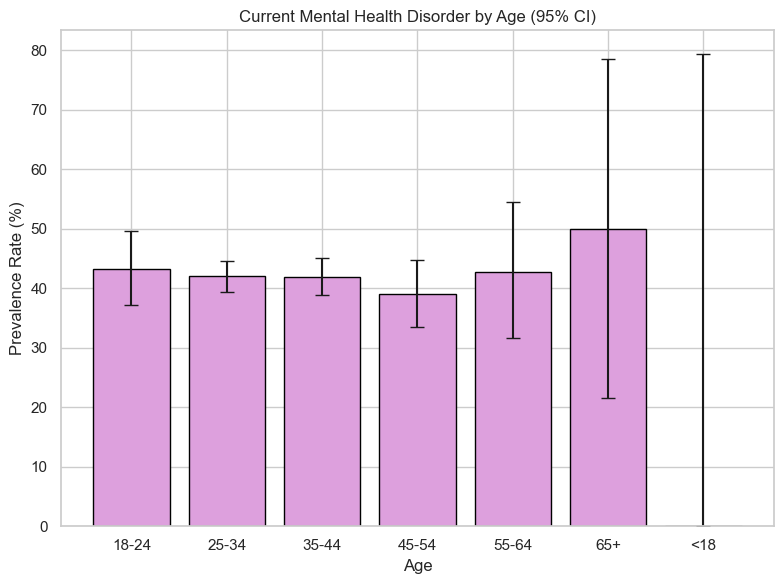

|  | Age Group | Yes (%) | CI Lower | CI Upper |
| --- | --- | --- | --- | --- |
| 3 | 18-24 | 43.28 | 37.14 | 49.63 |
| 1 | 25-34 | 42.01 | 39.43 | 44.63 |
| 0 | 35-44 | 41.94 | 38.87 | 45.08 |
| 2 | 45-54 | 38.95 | 33.47 | 44.72 |
| 5 | 55-64 | 42.65 | 31.60 | 54.48 |
| 6 | 65+ | 50.00 | 21.52 | 78.48 |
| 4 | <18 | 0.00 | 0.00 | 79.35 |

Note: <18 and 65+ age groups had very limited data (the outliers we have previously explored). These rows are included for transparency but should not be the basis for conclusions.

Prevalence rates across most age groups are relatively consistent, hovering around 40-44%. The 25–44 age groups had the most stable results, supported by larger sample sizes and narrower confidence intervals.

## Conclusion

In this project, I analyzed the Mental Health in the Tech Industry dataset by cleaning, organizing, and statistically exploring key mental health questions using SQL, pandas, and visualization tools. My main goal was to uncover meaningful patterns related to mental health status, gender, and age—and to communicate not only the findings, but also the uncertainty around them.

Some key findings that were uncovered:

- A high percentage of survey respondents claim to have had a mental health disorder in the past (around 47%) or had a diagnosis (46%). This shows that a large portion of individuals in the tech field have experienced mental health challenges.
- Female respondents reported a higher rate of current mental health disorders (≈47%) than male respondents (≈34%) in the analyzed sample.
- Confidence intervals provided clarity. By calculating 95% confidence intervals for all major proportions, I was able to visualize the potential range in which the true population values lie. This added transparency and reminded us not to overinterpret small differences, especially where sample sizes varied.
- In terms of Mental health insights related to age, the 25–44 age groups offered the most stable and reliable insights due to larger sample sizes.

The dataset provides a lot of freedom to explore. A more in-depth analysis could be performed in the future, focusing on a variety of features and their correlation.